# Investigating what affects if I finish watching a whole video on Youtube

## Finishing Youtube videos

Recently I’ve noticed that the number of videos on Youtube that I start watching but click off partial through has increased. Is it because I didn’t find the video interesting or is there another factor affecting my attention span. I wanted to investigate multiple factors related to the videos I’ve watched and see if there was another reason that I’m not finishing these videos.

## Does the genre affect if I finish the video?

The first factor I wanted to investigate was the genre of the videos that I was watching and try to find out if there were certain genres that I would fully watch more or less

## Graph 1

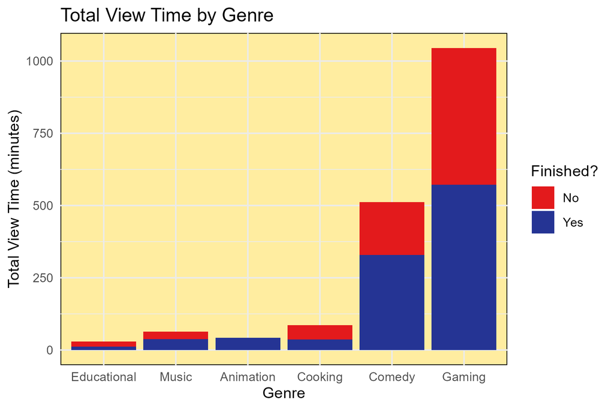

## Graph 2

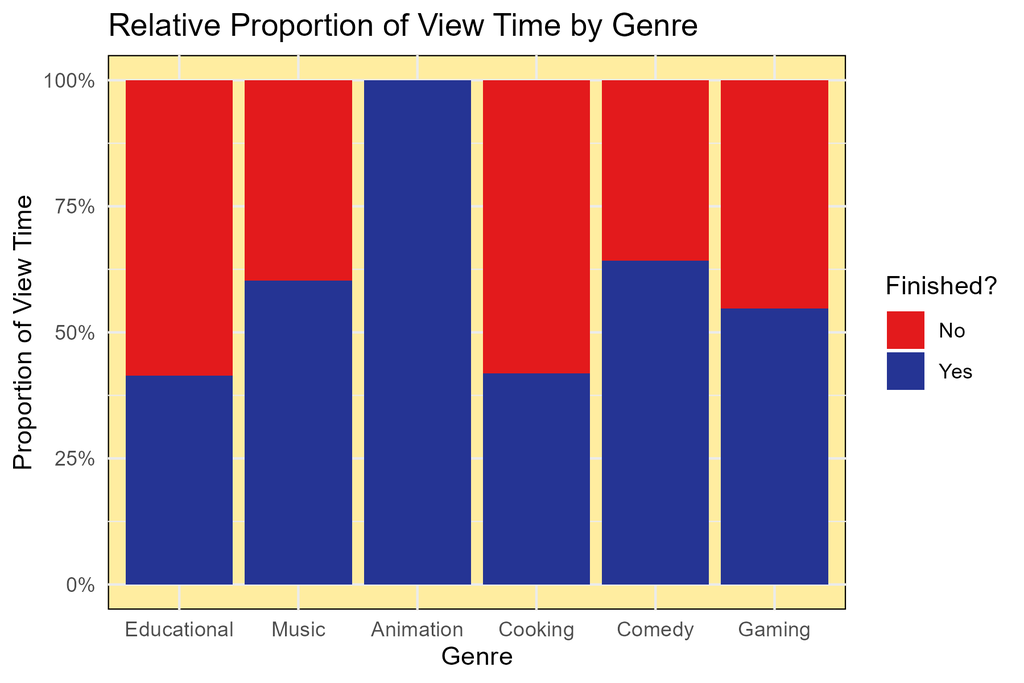

In this graph we get a better look at the proportion of video that were finished or not by genre. Some points of interest from this graph is that I fully watched 100% of animation videos with the second highest amount of finished videos being music and comedy. Another point to highlight is the genres with the highest percentage of unfinished video are cooking and educational, however educational has the lowest amount of view time so it’s difficult to determine if the educational genre had an effect on whether or not I finished the video.

These graphs tell us that I’m more likely to finish watching the video if the genre is animation and less likely to finish the video if the genre is cooking.

## Does the channel that uploaded the video affect if I finish the video?

The second factor I investigated was the channel that uploaded the video to see if there were any channels that I had a preference to finish the whole video or not.

## Graph 1

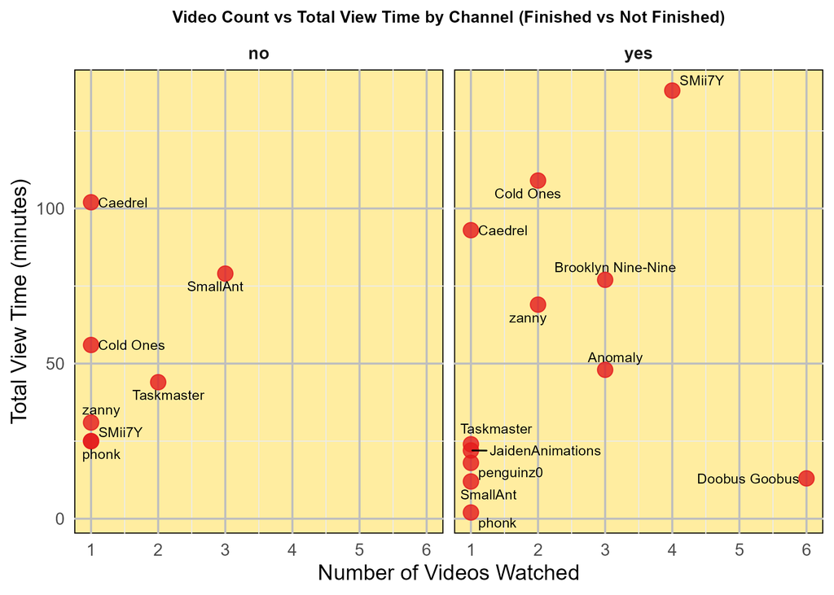

In this graph we have two graphs comparing the number of video watched by the total watch time of multiple channels split by whether they were finished or not. Important points of interest are on the not finished side the channel with the most unfinished videos is SmallAnt and on the finished side the channels with the most videos are SMii7Y and Doobus Goobus, however we can see a distinct difference in the amount of view time between these channels.

## Graph 2

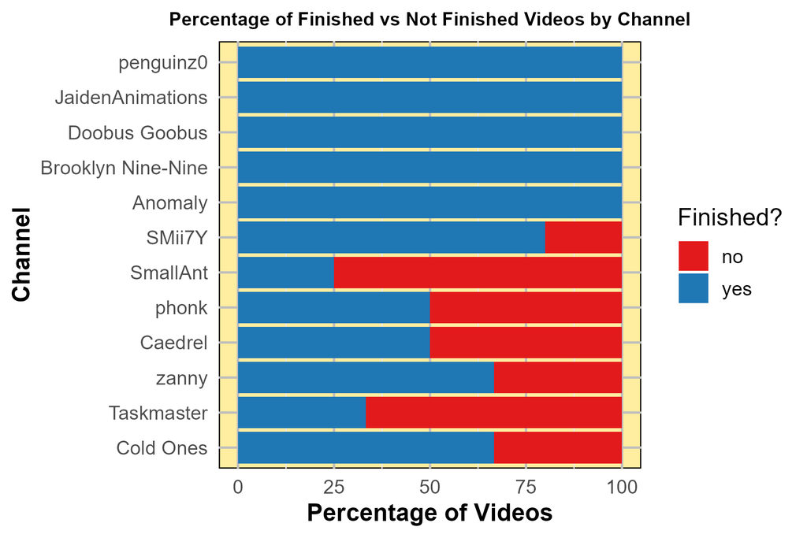

In this graph we take a closer look at the percentage of finished and unfinished videos by channel. Again we see that SmallAnt has the lowest amount of finished videos with Taskmaster in a close second and penguinz0, JaidenAnimations, Doobus Goobus, Brooklyn Nine-Nine and Anomaly all have 100% finished videos. However we shouldn’t count penguinz0 and JaidenAnimations as they both only have one video.

From these graphs we can say that the channel that uploaded the video can have some effect on whether or not I finish the video but that affect can vary depending on the channel

## Does the time at which I watched the video affect if I finish the video?

I third factor I investigated was if the time of day that I watched the video at had any affect on whether or not I finished the video

## Graph 1

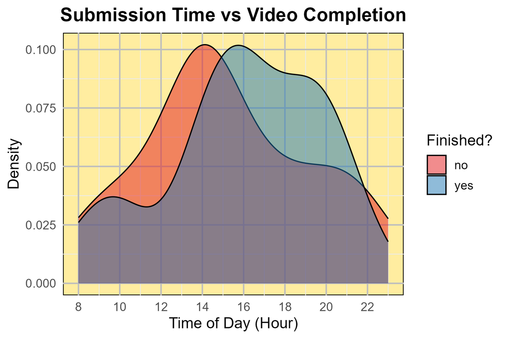

From this graph we can see that the most common time that I watch videos at is between 2pm to 4pm but we can also see that I don’t finish more videos in the morning hours (10am - 1pm) and finish more videos in the evening hours (4pm - 9pm).

From this graph we can determine that I’m more likely to not finish the video in the morning hours, I have a 50/50 chance to finish or not finish the video around the midday hours and I’m more likely to finish the video in the evening hours.

## Conclusion

Based on the data collected and data complied into graphs to determine if there are other factors that may influence my choice of whether or not I complete watching a full Youtube video, it does appear that there are some factors that influence it.

For genre it does appear that I’m more likely to finish watching a video if the genre is animation and less likely to finish the video if the genre is cooking.

For channel it does appear that I’m more likely to finish videos from certain channels as I;m less likely to finish videos from SmallAnt but more likely to finish videos from Anomaly or Brooklyn Nine-Nine

For the time I watched the video at it appears that I’m more likely to finish the video if I watch it in the evening and less likely to finish it if I watch it in the morning.